#### 2. The Model with the Lowest Forecast RMSE

```
RMSEs
                 Lag8
EmploymentDif1 143.26
CPIDif1          0.77
Sum            144.03
```

```
VAR Estimation Results:
=======================

Estimated coefficients for equation EmploymentDif1:
===================================================
Call:
EmploymentDif1 = EmploymentDif1.l1 + CPIDif1.l1 + EmploymentDif1.l2 + CPIDif1.l2 + EmploymentDif1.l3 + CPIDif1.l3 + EmploymentDif1.l4 + CPIDif1.l4 + EmploymentDif1.l5 + CPIDif1.l5 + EmploymentDif1.l6 + CPIDif1.l6 + EmploymentDif1.l7 + CPIDif1.l7 + EmploymentDif1.l8 + CPIDif1.l8 + IPIDif1

EmploymentDif1.l1        CPIDif1.l1 EmploymentDif1.l2        CPIDif1.l2
      0.084649340     -36.374133553       0.250163142      29.575397016
EmploymentDif1.l3        CPIDif1.l3 EmploymentDif1.l4        CPIDif1.l4
      0.181059049     -19.165172308       0.089049784     -22.736362556
EmploymentDif1.l5        CPIDif1.l5 EmploymentDif1.l6        CPIDif1.l6
      0.090168411      -0.797584670       0.005356398      19.342461589
EmploymentDif1.l7        CPIDif1.l7 EmploymentDif1.l8        CPIDif1.l8
     -0.008894791     -29.413297749       0.041662178      76.359871816
          IPIDif1
    210.146414848


Estimated coefficients for equation CPIDif1:
============================================
Call:
CPIDif1 = EmploymentDif1.l1 + CPIDif1.l1 + EmploymentDif1.l2 + CPIDif1.l2 + EmploymentDif1.l3 + CPIDif1.l3 + EmploymentDif1.l4 + CPIDif1.l4 + EmploymentDif1.l5 + CPIDif1.l5 + EmploymentDif1.l6 + CPIDif1.l6 + EmploymentDif1.l7 + CPIDif1.l7 + EmploymentDif1.l8 + CPIDif1.l8 + IPIDif1

EmploymentDif1.l1        CPIDif1.l1 EmploymentDif1.l2        CPIDif1.l2
     5.115565e-05      3.959533e-01      1.943303e-04     -1.136132e-01
EmploymentDif1.l3        CPIDif1.l3 EmploymentDif1.l4        CPIDif1.l4
     5.553231e-05      1.360178e-01      6.761504e-05      9.144895e-02
EmploymentDif1.l5        CPIDif1.l5 EmploymentDif1.l6        CPIDif1.l6
    -8.610523e-05      6.146060e-02     -1.032896e-04      1.447243e-01
EmploymentDif1.l7        CPIDif1.l7 EmploymentDif1.l8        CPIDif1.l8
    -1.213970e-05      6.183146e-02     -1.626342e-06      1.289042e-01
          IPIDif1
     3.323615e-02
```

#### 3. Forecast the Best Model

Employment 1st Diff and Inflation 1st Diff as endogenous variables, IPI 1st Diff as exogenous variable, no constant, no season, lag=8.

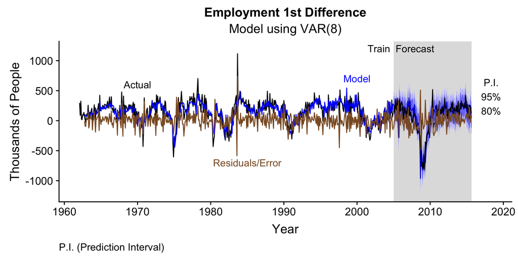

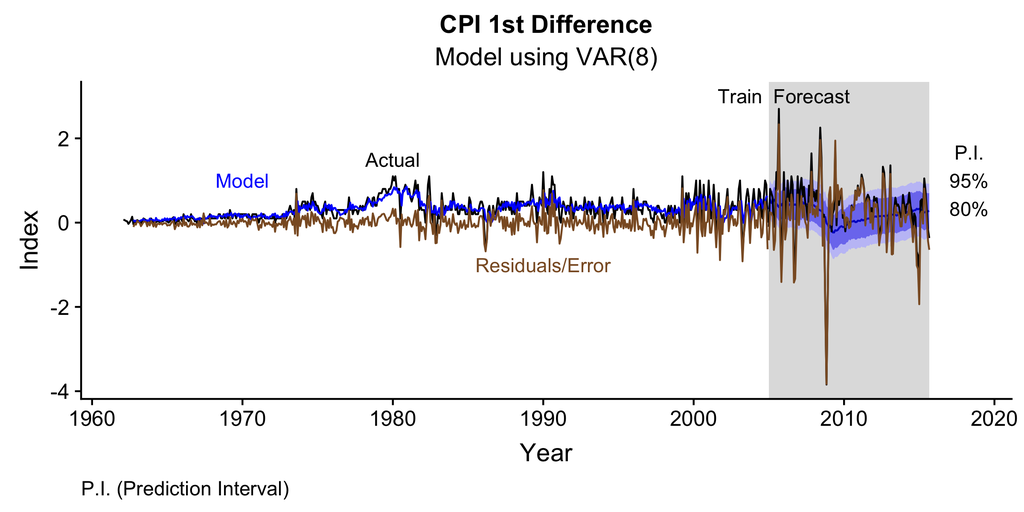

#### 4. Analyze the Forecast Error of the Best Model

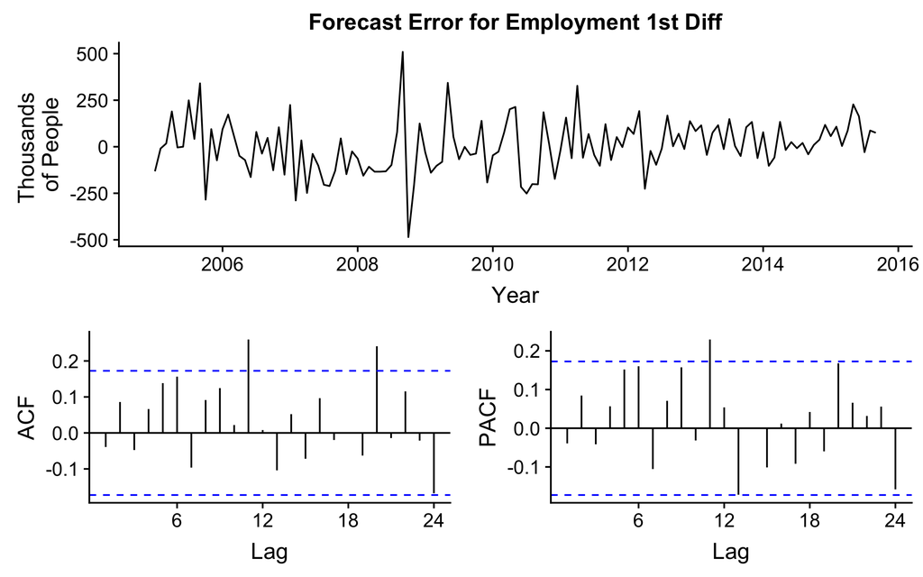

Employment 1st Diff forecast error passes the ADF test up to 24 lags and passes the Ljung-Box test up to 10 lags when critical value=5%. The correlogram suggests no ARMA effect.

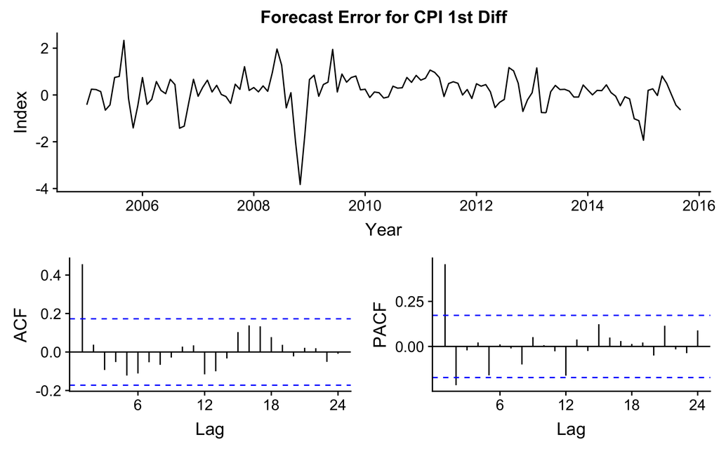

Next, I can convert the first-differneces back to levels, and compare the performances in levels.

rmarkdown::render(“U5P3.rmd”)